# Risk Factor Analysis

## Outcome Variable

**Outcome Variable:** haz

## Predictor Variables

**Intervention Variable:** exclfeed36

**Adjustment Set:**

unadjusted

## Stratifying Variables

The analysis was stratified on these variable(s):

- agecat
- studyid
- country

## Data Summary

| agecat | studyid | country | exclfeed36 | n_cell | n |
| --- | --- | --- | --- | --- | --- |
| Birth | CMC-V-BCS-2002 | INDIA | 1 | 3 | 3 |
| Birth | CMC-V-BCS-2002 | INDIA | 0 | 0 | 3 |
| Birth | EE | PAKISTAN | 1 | 3 | 7 |
| Birth | EE | PAKISTAN | 0 | 4 | 7 |
| Birth | GMS-Nepal | NEPAL | 1 | 422 | 526 |
| Birth | GMS-Nepal | NEPAL | 0 | 104 | 526 |
| Birth | IRC | INDIA | 1 | 0 | 4 |
| Birth | IRC | INDIA | 0 | 4 | 4 |
| Birth | Keneba | GAMBIA | 1 | 363 | 1253 |
| Birth | Keneba | GAMBIA | 0 | 890 | 1253 |
| Birth | MAL-ED | BANGLADESH | 1 | 32 | 221 |
| Birth | MAL-ED | BANGLADESH | 0 | 189 | 221 |
| Birth | MAL-ED | BRAZIL | 1 | 5 | 65 |
| Birth | MAL-ED | BRAZIL | 0 | 60 | 65 |
| Birth | MAL-ED | INDIA | 1 | 1 | 42 |
| Birth | MAL-ED | INDIA | 0 | 41 | 42 |
| Birth | MAL-ED | NEPAL | 1 | 0 | 26 |
| Birth | MAL-ED | NEPAL | 0 | 26 | 26 |
| Birth | MAL-ED | PERU | 1 | 5 | 223 |
| Birth | MAL-ED | PERU | 0 | 218 | 223 |
| Birth | MAL-ED | SOUTH AFRICA | 1 | 1 | 105 |
| Birth | MAL-ED | SOUTH AFRICA | 0 | 104 | 105 |
| Birth | MAL-ED | TANZANIA, UNITED REPUBLIC OF | 1 | 0 | 119 |
| Birth | MAL-ED | TANZANIA, UNITED REPUBLIC OF | 0 | 119 | 119 |
| Birth | PROVIDE | BANGLADESH | 1 | 119 | 490 |
| Birth | PROVIDE | BANGLADESH | 0 | 371 | 490 |
| 6 months | CMC-V-BCS-2002 | INDIA | 1 | 9 | 9 |
| 6 months | CMC-V-BCS-2002 | INDIA | 0 | 0 | 9 |
| 6 months | EE | PAKISTAN | 1 | 4 | 9 |
| 6 months | EE | PAKISTAN | 0 | 5 | 9 |

[output cut: 54 more lines]

The following strata were considered:

- agecat: 24 months, studyid: CMC-V-BCS-2002, country: INDIA
- agecat: 24 months, studyid: EE, country: PAKISTAN
- agecat: 24 months, studyid: GMS-Nepal, country: NEPAL
- agecat: 24 months, studyid: IRC, country: INDIA
- agecat: 24 months, studyid: Keneba, country: GAMBIA
- agecat: 24 months, studyid: LCNI-5, country: MALAWI
- agecat: 24 months, studyid: MAL-ED, country: BANGLADESH
- agecat: 24 months, studyid: MAL-ED, country: BRAZIL
- agecat: 24 months, studyid: MAL-ED, country: INDIA
- agecat: 24 months, studyid: MAL-ED, country: NEPAL
- agecat: 24 months, studyid: MAL-ED, country: PERU
- agecat: 24 months, studyid: MAL-ED, country: SOUTH AFRICA
- agecat: 24 months, studyid: MAL-ED, country: TANZANIA, UNITED REPUBLIC OF
- agecat: 24 months, studyid: PROVIDE, country: BANGLADESH
- agecat: 6 months, studyid: CMC-V-BCS-2002, country: INDIA
- agecat: 6 months, studyid: EE, country: PAKISTAN
- agecat: 6 months, studyid: GMS-Nepal, country: NEPAL
- agecat: 6 months, studyid: IRC, country: INDIA
- agecat: 6 months, studyid: Keneba, country: GAMBIA
- agecat: 6 months, studyid: LCNI-5, country: MALAWI
- agecat: 6 months, studyid: MAL-ED, country: BANGLADESH
- agecat: 6 months, studyid: MAL-ED, country: BRAZIL
- agecat: 6 months, studyid: MAL-ED, country: INDIA
- agecat: 6 months, studyid: MAL-ED, country: NEPAL
- agecat: 6 months, studyid: MAL-ED, country: PERU
- agecat: 6 months, studyid: MAL-ED, country: SOUTH AFRICA
- agecat: 6 months, studyid: MAL-ED, country: TANZANIA, UNITED REPUBLIC OF
- agecat: 6 months, studyid: PROVIDE, country: BANGLADESH
- agecat: 6 months, studyid: SAS-FoodSuppl, country: INDIA
- agecat: Birth, studyid: CMC-V-BCS-2002, country: INDIA
- agecat: Birth, studyid: EE, country: PAKISTAN
- agecat: Birth, studyid: GMS-Nepal, country: NEPAL
- agecat: Birth, studyid: IRC, country: INDIA
- agecat: Birth, studyid: Keneba, country: GAMBIA
- agecat: Birth, studyid: MAL-ED, country: BANGLADESH
- agecat: Birth, studyid: MAL-ED, country: BRAZIL
- agecat: Birth, studyid: MAL-ED, country: INDIA
- agecat: Birth, studyid: MAL-ED, country: NEPAL
- agecat: Birth, studyid: MAL-ED, country: PERU
- agecat: Birth, studyid: MAL-ED, country: SOUTH AFRICA
- agecat: Birth, studyid: MAL-ED, country: TANZANIA, UNITED REPUBLIC OF
- agecat: Birth, studyid: PROVIDE, country: BANGLADESH

### Dropped Strata

- agecat: Birth, studyid: CMC-V-BCS-2002, country: INDIA
- agecat: Birth, studyid: EE, country: PAKISTAN
- agecat: Birth, studyid: IRC, country: INDIA
- agecat: Birth, studyid: MAL-ED, country: INDIA
- agecat: Birth, studyid: MAL-ED, country: NEPAL
- agecat: Birth, studyid: MAL-ED, country: SOUTH AFRICA
- agecat: Birth, studyid: MAL-ED, country: TANZANIA, UNITED REPUBLIC OF
- agecat: 6 months, studyid: CMC-V-BCS-2002, country: INDIA
- agecat: 6 months, studyid: EE, country: PAKISTAN
- agecat: 6 months, studyid: IRC, country: INDIA
- agecat: 6 months, studyid: MAL-ED, country: NEPAL
- agecat: 6 months, studyid: MAL-ED, country: SOUTH AFRICA
- agecat: 6 months, studyid: MAL-ED, country: TANZANIA, UNITED REPUBLIC OF
- agecat: 6 months, studyid: SAS-FoodSuppl, country: INDIA
- agecat: 24 months, studyid: CMC-V-BCS-2002, country: INDIA
- agecat: 24 months, studyid: EE, country: PAKISTAN
- agecat: 24 months, studyid: IRC, country: INDIA
- agecat: 24 months, studyid: MAL-ED, country: NEPAL
- agecat: 24 months, studyid: MAL-ED, country: PERU
- agecat: 24 months, studyid: MAL-ED, country: SOUTH AFRICA
- agecat: 24 months, studyid: MAL-ED, country: TANZANIA, UNITED REPUBLIC OF

## Methods Detail

We’re interested in the causal parameters $E[Y_a]$ for all values of $a \in \mathcal{A}$. These parameters represent the mean outcome if, possibly contrary to fact, we intervened to set all units to have $A=a$. Under the randomization and positivity assumptions, these are identified by the statistical parameters $\psi_a=E_W[E_{Y|A,W}(Y|A=a,W)]$. In addition, we’re interested in the mean of $Y$, $E[Y]$ under no intervention (the observed mean). We will estimate these parameters by using SuperLearner to fit the relevant likelihood factors – $E_{Y|A,W}(Y|A=a,W)$ and $p(A=a|W)$, and then updating our likelihood fit using a joint TMLE.

For unadjusted analyses ($W=\{\}$), initial likelihoods were estimated using Lrnr_glm to estimate the simple $E(Y|A)$ and Lrnr_mean to estimate $p(A)$. For adjusted analyses, a small library containing Lrnr_glmnet, Lrnr_xgboost, and Lrnr_mean was used.

Having estimated these parameters, we will then use the delta method to estimate relative risks and attributable risks relative to a prespecified baseline level of $A$.

# Results Detail

## Results Plots

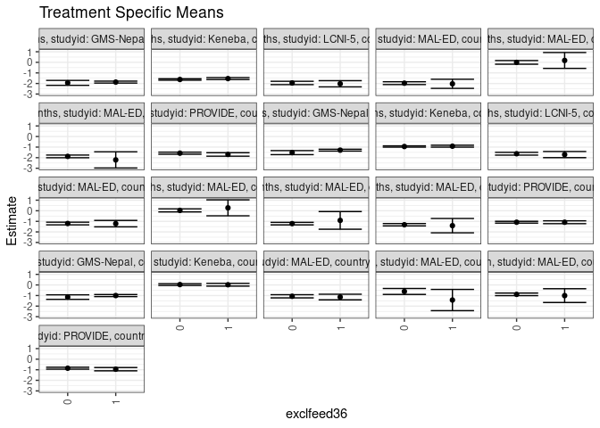

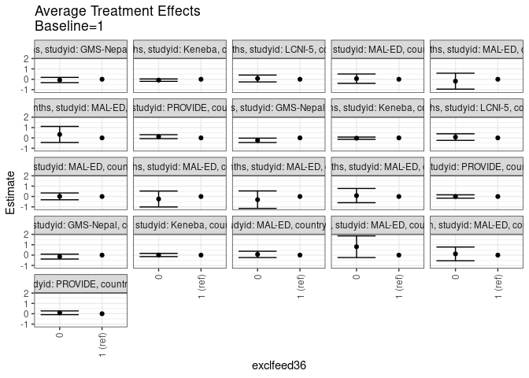

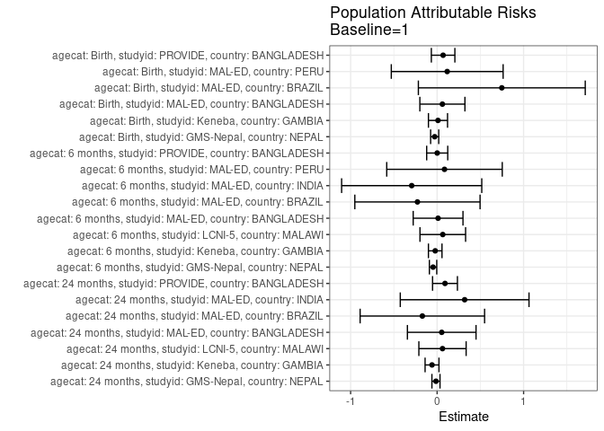

## Results Table

### Parameter: TSM

| agecat | studyid | country | intervention_level | baseline_level | estimate | ci_lower | ci_upper |
| --- | --- | --- | --- | --- | --- | --- | --- |
| Birth | GMS-Nepal | NEPAL | 1 | NA | -1.0018009 | -1.0995626 | -0.9040393 |
| Birth | GMS-Nepal | NEPAL | 0 | NA | -1.1442308 | -1.3584754 | -0.9299861 |
| Birth | Keneba | GAMBIA | 1 | NA | 0.0217769 | -0.1084768 | 0.1520306 |
| Birth | Keneba | GAMBIA | 0 | NA | 0.0359101 | -0.0489370 | 0.1207572 |
| Birth | MAL-ED | BANGLADESH | 1 | NA | -1.1412500 | -1.4056727 | -0.8768273 |
| Birth | MAL-ED | BANGLADESH | 0 | NA | -1.0698942 | -1.2211049 | -0.9186835 |
| Birth | MAL-ED | BRAZIL | 1 | NA | -1.4240000 | -2.4288338 | -0.4191662 |
| Birth | MAL-ED | BRAZIL | 0 | NA | -0.6136667 | -0.8950902 | -0.3322431 |
| Birth | MAL-ED | PERU | 1 | NA | -1.0080000 | -1.6595862 | -0.3564138 |
| Birth | MAL-ED | PERU | 0 | NA | -0.8886239 | -1.0108291 | -0.7664186 |
| Birth | PROVIDE | BANGLADESH | 1 | NA | -0.9462185 | -1.1006724 | -0.7917646 |
| Birth | PROVIDE | BANGLADESH | 0 | NA | -0.8547439 | -0.9464721 | -0.7630158 |
| 6 months | GMS-Nepal | NEPAL | 1 | NA | -1.2868918 | -1.3738868 | -1.1998968 |
| 6 months | GMS-Nepal | NEPAL | 0 | NA | -1.5221429 | -1.7134970 | -1.3307887 |
| 6 months | Keneba | GAMBIA | 1 | NA | -0.9135184 | -1.0048201 | -0.8222167 |
| 6 months | Keneba | GAMBIA | 0 | NA | -0.9443010 | -1.0044753 | -0.8841268 |
| 6 months | LCNI-5 | MALAWI | 1 | NA | -1.7051064 | -1.9955729 | -1.4146399 |
| 6 months | LCNI-5 | MALAWI | 0 | NA | -1.6259111 | -1.7571663 | -1.4946560 |
| 6 months | MAL-ED | BANGLADESH | 1 | NA | -1.2184444 | -1.5218323 | -0.9150566 |
| 6 months | MAL-ED | BANGLADESH | 0 | NA | -1.2056667 | -1.3329154 | -1.0784180 |
| 6 months | MAL-ED | BRAZIL | 1 | NA | 0.2750000 | -0.4792287 | 1.0292287 |
| 6 months | MAL-ED | BRAZIL | 0 | NA | 0.0337225 | -0.1116704 | 0.1791154 |
| 6 months | MAL-ED | INDIA | 1 | NA | -0.9116667 | -1.7458275 | -0.0775058 |
| 6 months | MAL-ED | INDIA | 0 | NA | -1.2173884 | -1.3368172 | -1.0979596 |
| 6 months | MAL-ED | PERU | 1 | NA | -1.4083333 | -2.0844008 | -0.7322659 |
| 6 months | MAL-ED | PERU | 0 | NA | -1.3211685 | -1.4309807 | -1.2113564 |
| 6 months | PROVIDE | BANGLADESH | 1 | NA | -1.0866207 | -1.2211854 | -0.9520560 |
| 6 months | PROVIDE | BANGLADESH | 0 | NA | -1.0852220 | -1.1722131 | -0.9982308 |
| 24 months | GMS-Nepal | NEPAL | 1 | NA | -1.8696786 | -1.9637288 | -1.7756284 |
| 24 months | GMS-Nepal | NEPAL | 0 | NA | -1.9416466 | -2.1743549 | -1.7089382 |
| 24 months | Keneba | GAMBIA | 1 | NA | -1.5392740 | -1.6320610 | -1.4464870 |
| 24 months | Keneba | GAMBIA | 0 | NA | -1.6239510 | -1.6922300 | -1.5556721 |
| 24 months | LCNI-5 | MALAWI | 1 | NA | -2.0273529 | -2.3204751 | -1.7342307 |
| 24 months | LCNI-5 | MALAWI | 0 | NA | -1.9514839 | -2.1097913 | -1.7931764 |
| 24 months | MAL-ED | BANGLADESH | 1 | NA | -2.0316000 | -2.4616615 | -1.6015385 |
| 24 months | MAL-ED | BANGLADESH | 0 | NA | -1.9712834 | -2.1027863 | -1.8397805 |
| 24 months | MAL-ED | BRAZIL | 1 | NA | 0.1768182 | -0.5731823 | 0.9268187 |
| 24 months | MAL-ED | BRAZIL | 0 | NA | -0.0057700 | -0.1783407 | 0.1668006 |
| 24 months | MAL-ED | INDIA | 1 | NA | -2.2088889 | -2.9737293 | -1.4440485 |
| 24 months | MAL-ED | INDIA | 0 | NA | -1.8773023 | -2.0042653 | -1.7503393 |
| 24 months | PROVIDE | BANGLADESH | 1 | NA | -1.6932979 | -1.8569446 | -1.5296512 |
| 24 months | PROVIDE | BANGLADESH | 0 | NA | -1.5728326 | -1.6696229 | -1.4760423 |

### Parameter: E(Y)

| agecat | studyid | country | intervention_level | baseline_level | estimate | ci_lower | ci_upper |
| --- | --- | --- | --- | --- | --- | --- | --- |
| Birth | GMS-Nepal | NEPAL | NA | NA | -1.0299620 | -1.1192344 | -0.9406896 |
| Birth | Keneba | GAMBIA | NA | NA | 0.0318156 | -0.0392907 | 0.1029220 |
| Birth | MAL-ED | BANGLADESH | NA | NA | -1.0802262 | -1.2151319 | -0.9453206 |
| Birth | MAL-ED | BRAZIL | NA | NA | -0.6760000 | -0.9521457 | -0.3998543 |
| Birth | MAL-ED | PERU | NA | NA | -0.8913004 | -1.0115814 | -0.7710195 |
| Birth | PROVIDE | BANGLADESH | NA | NA | -0.8769592 | -0.9559693 | -0.7979491 |
| 6 months | GMS-Nepal | NEPAL | NA | NA | -1.3337634 | -1.4135810 | -1.2539459 |
| 6 months | Keneba | GAMBIA | NA | NA | -0.9355822 | -0.9858754 | -0.8852889 |
| 6 months | LCNI-5 | MALAWI | NA | NA | -1.6395956 | -1.7592633 | -1.5199278 |
| 6 months | MAL-ED | BANGLADESH | NA | NA | -1.2072639 | -1.3248889 | -1.0896388 |
| 6 months | MAL-ED | BRAZIL | NA | NA | 0.0475758 | -0.0963508 | 0.1915023 |
| 6 months | MAL-ED | INDIA | NA | NA | -1.2055794 | -1.3250712 | -1.0860876 |
| 6 months | MAL-ED | PERU | NA | NA | -1.3230913 | -1.4314947 | -1.2146879 |
| 6 months | PROVIDE | BANGLADESH | NA | NA | -1.0855583 | -1.1591292 | -1.0119875 |
| 24 months | GMS-Nepal | NEPAL | NA | NA | -1.8830717 | -1.9710591 | -1.7950844 |
| 24 months | Keneba | GAMBIA | NA | NA | -1.5981956 | -1.6534947 | -1.5428965 |
| 24 months | LCNI-5 | MALAWI | NA | NA | -1.9651323 | -2.1053230 | -1.8249415 |
| 24 months | MAL-ED | BANGLADESH | NA | NA | -1.9783962 | -2.1050210 | -1.8517715 |
| 24 months | MAL-ED | BRAZIL | NA | NA | 0.0061144 | -0.1625850 | 0.1748138 |
| 24 months | MAL-ED | INDIA | NA | NA | -1.8906250 | -2.0165920 | -1.7646580 |
| 24 months | PROVIDE | BANGLADESH | NA | NA | -1.6022704 | -1.6857342 | -1.5188065 |

### Parameter: ATE

| agecat | studyid | country | intervention_level | baseline_level | estimate | ci_lower | ci_upper |
| --- | --- | --- | --- | --- | --- | --- | --- |
| Birth | GMS-Nepal | NEPAL | 1 | 1 | 0.0000000 | 0.0000000 | 0.0000000 |
| Birth | GMS-Nepal | NEPAL | 0 | 1 | -0.1424298 | -0.3779253 | 0.0930656 |
| Birth | Keneba | GAMBIA | 1 | 1 | 0.0000000 | 0.0000000 | 0.0000000 |
| Birth | Keneba | GAMBIA | 0 | 1 | 0.0141333 | -0.1413179 | 0.1695844 |
| Birth | MAL-ED | BANGLADESH | 1 | 1 | 0.0000000 | 0.0000000 | 0.0000000 |
| Birth | MAL-ED | BANGLADESH | 0 | 1 | 0.0713558 | -0.2332489 | 0.3759606 |
| Birth | MAL-ED | BRAZIL | 1 | 1 | 0.0000000 | 0.0000000 | 0.0000000 |
| Birth | MAL-ED | BRAZIL | 0 | 1 | 0.8103333 | -0.2331657 | 1.8538323 |
| Birth | MAL-ED | PERU | 1 | 1 | 0.0000000 | 0.0000000 | 0.0000000 |
| Birth | MAL-ED | PERU | 0 | 1 | 0.1193761 | -0.5435709 | 0.7823232 |
| Birth | PROVIDE | BANGLADESH | 1 | 1 | 0.0000000 | 0.0000000 | 0.0000000 |
| Birth | PROVIDE | BANGLADESH | 0 | 1 | 0.0914746 | -0.0881642 | 0.2711133 |
| 6 months | GMS-Nepal | NEPAL | 1 | 1 | 0.0000000 | 0.0000000 | 0.0000000 |
| 6 months | GMS-Nepal | NEPAL | 0 | 1 | -0.2352511 | -0.4454522 | -0.0250499 |
| 6 months | Keneba | GAMBIA | 1 | 1 | 0.0000000 | 0.0000000 | 0.0000000 |
| 6 months | Keneba | GAMBIA | 0 | 1 | -0.0307826 | -0.1401304 | 0.0785652 |
| 6 months | LCNI-5 | MALAWI | 1 | 1 | 0.0000000 | 0.0000000 | 0.0000000 |
| 6 months | LCNI-5 | MALAWI | 0 | 1 | 0.0791953 | -0.2395502 | 0.3979408 |
| 6 months | MAL-ED | BANGLADESH | 1 | 1 | 0.0000000 | 0.0000000 | 0.0000000 |
| 6 months | MAL-ED | BANGLADESH | 0 | 1 | 0.0127778 | -0.3162152 | 0.3417708 |
| 6 months | MAL-ED | BRAZIL | 1 | 1 | 0.0000000 | 0.0000000 | 0.0000000 |
| 6 months | MAL-ED | BRAZIL | 0 | 1 | -0.2412775 | -1.0093921 | 0.5268371 |
| 6 months | MAL-ED | INDIA | 1 | 1 | 0.0000000 | 0.0000000 | 0.0000000 |
| 6 months | MAL-ED | INDIA | 0 | 1 | -0.3057217 | -1.1483886 | 0.5369452 |
| 6 months | MAL-ED | PERU | 1 | 1 | 0.0000000 | 0.0000000 | 0.0000000 |
| 6 months | MAL-ED | PERU | 0 | 1 | 0.0871648 | -0.5977629 | 0.7720924 |
| 6 months | PROVIDE | BANGLADESH | 1 | 1 | 0.0000000 | 0.0000000 | 0.0000000 |
| 6 months | PROVIDE | BANGLADESH | 0 | 1 | 0.0013987 | -0.1588358 | 0.1616333 |
| 24 months | GMS-Nepal | NEPAL | 1 | 1 | 0.0000000 | 0.0000000 | 0.0000000 |
| 24 months | GMS-Nepal | NEPAL | 0 | 1 | -0.0719680 | -0.3229632 | 0.1790273 |
| 24 months | Keneba | GAMBIA | 1 | 1 | 0.0000000 | 0.0000000 | 0.0000000 |
| 24 months | Keneba | GAMBIA | 0 | 1 | -0.0846771 | -0.1998788 | 0.0305247 |
| 24 months | LCNI-5 | MALAWI | 1 | 1 | 0.0000000 | 0.0000000 | 0.0000000 |
| 24 months | LCNI-5 | MALAWI | 0 | 1 | 0.0758691 | -0.2572704 | 0.4090085 |
| 24 months | MAL-ED | BANGLADESH | 1 | 1 | 0.0000000 | 0.0000000 | 0.0000000 |
| 24 months | MAL-ED | BANGLADESH | 0 | 1 | 0.0603166 | -0.3894010 | 0.5100342 |
| 24 months | MAL-ED | BRAZIL | 1 | 1 | 0.0000000 | 0.0000000 | 0.0000000 |
| 24 months | MAL-ED | BRAZIL | 0 | 1 | -0.1825882 | -0.9521864 | 0.5870100 |
| 24 months | MAL-ED | INDIA | 1 | 1 | 0.0000000 | 0.0000000 | 0.0000000 |
| 24 months | MAL-ED | INDIA | 0 | 1 | 0.3315866 | -0.4437201 | 1.1068933 |
| 24 months | PROVIDE | BANGLADESH | 1 | 1 | 0.0000000 | 0.0000000 | 0.0000000 |
| 24 months | PROVIDE | BANGLADESH | 0 | 1 | 0.1204653 | -0.0696626 | 0.3105932 |

### Parameter: PAR

| agecat | studyid | country | intervention_level | baseline_level | estimate | ci_lower | ci_upper |
| --- | --- | --- | --- | --- | --- | --- | --- |
| Birth | GMS-Nepal | NEPAL | 1 | NA | -0.0281610 | -0.0749750 | 0.0186530 |
| Birth | Keneba | GAMBIA | 1 | NA | 0.0100388 | -0.1003780 | 0.1204555 |
| Birth | MAL-ED | BANGLADESH | 1 | NA | 0.0610238 | -0.1994964 | 0.3215440 |
| Birth | MAL-ED | BRAZIL | 1 | NA | 0.7480000 | -0.2166815 | 1.7126815 |
| Birth | MAL-ED | PERU | 1 | NA | 0.1166996 | -0.5296780 | 0.7630771 |
| Birth | PROVIDE | BANGLADESH | 1 | NA | 0.0692593 | -0.0667973 | 0.2053159 |
| 6 months | GMS-Nepal | NEPAL | 1 | NA | -0.0468717 | -0.0895153 | -0.0042281 |
| 6 months | Keneba | GAMBIA | 1 | NA | -0.0220637 | -0.1004425 | 0.0563150 |
| 6 months | LCNI-5 | MALAWI | 1 | NA | 0.0655108 | -0.1981815 | 0.3292031 |
| 6 months | MAL-ED | BANGLADESH | 1 | NA | 0.0111806 | -0.2766888 | 0.2990499 |
| 6 months | MAL-ED | BRAZIL | 1 | NA | -0.2274242 | -0.9514768 | 0.4966283 |
| 6 months | MAL-ED | INDIA | 1 | NA | -0.2939127 | -1.1040658 | 0.5162403 |
| 6 months | MAL-ED | PERU | 1 | NA | 0.0852420 | -0.5825642 | 0.7530482 |
| 6 months | PROVIDE | BANGLADESH | 1 | NA | 0.0010624 | -0.1206415 | 0.1227662 |
| 24 months | GMS-Nepal | NEPAL | 1 | NA | -0.0133931 | -0.0601755 | 0.0333892 |
| 24 months | Keneba | GAMBIA | 1 | NA | -0.0589216 | -0.1391096 | 0.0212664 |
| 24 months | LCNI-5 | MALAWI | 1 | NA | 0.0622207 | -0.2110207 | 0.3354620 |
| 24 months | MAL-ED | BANGLADESH | 1 | NA | 0.0532038 | -0.3434898 | 0.4498973 |
| 24 months | MAL-ED | BRAZIL | 1 | NA | -0.1707038 | -0.8902420 | 0.5488345 |
| 24 months | MAL-ED | INDIA | 1 | NA | 0.3182639 | -0.4259412 | 1.0624690 |
| 24 months | PROVIDE | BANGLADESH | 1 | NA | 0.0910275 | -0.0527015 | 0.2347565 |